# Introduction to R for data analysis

IPB DoCou

Guillaume Patoine, Anjana Bhat

MetaCom, IPB

2026-05-06

# Welcome

- Time: 13:00 to 15:30
- Place: Benno-Parthier Saal, IPB Halle + Teams Meeting
- Short break ~ 14:10

Course materials are on GitHub. Download the folder to follow-along:

https://github.com/gpatoine/intro-R-course

Code -> Download ZIP

## About us

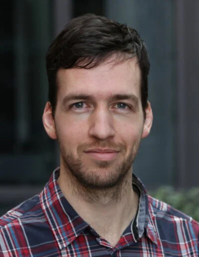

Guillaume Patoine

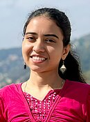

Anjana Bhat

[figure not shown]

[figure not shown]

Bioinformatics, Metabolomics, Multi-Omics

Software development and Data analysis

## Attendance

Please fill the form!

[figure not shown]

https://forms.office.com/e/SQUs6gXmCZ

# 1 Introduction

## What is R?

[figure not shown]

- Programming language for data analysis
  - Wrangling, statistics, visualization, reporting
- Free and open source
- Widely used in research and data science
- Dynamically typed (interpreted), not compiled

## Why use R?

[figure not shown]

- Reproducibility
  - Analyses can be saved, shared, and rerun
- Great community support
  - Tutorials, online help, etc.
- Extensive ecosystem of curated packages
  - Thousands of packages available
  - Specialized tools for many scientific fields
- Automation
  - Avoid repetitive manual work
  - Process large datasets efficiently

## RStudio

- Integrated Development Environment (IDE) for R
- Developed by Posit (formely RStudio, PBC)
- One IDE to rule them for all:
  - Scripts, console, plots, files, packages!

**Note**

**Positron** is the newer IDE from Posit. It resembles VS-Code and has better support for other languages than R.

[figure not shown]

[figure not shown]

## Installation

For IPB computers, install “Prod_R” and “Prod_RStudio” from the Company Portal (Unternehmensportal).

Otherwise install it from:

- R: https://cran.rstudio.com/
- RStudio: https://posit.co/download/rstudio-desktop

## Course philosophy

Knowledge is of two kinds. We know a subject ourselves,  
or we know where we can find information upon it.

- Samuel Johnson, 1791

- Quoted by Bjarne Stroustrup (creator of C++)

**Goals:**

- Give an overview of what is possible with R.
- Showcase the main concepts to get started.
- Empower you to find the information that you need when you need it.
- Don’t worry, you don’t need to remember everything.

## Course structure

- Main concepts are in the slides
- Follow-along in the file `course-script.R`
  - Run the code
  - Try things out (it won’t break)
  - Do exercises
- Ask questions, talk to your neighbors (during hands-on)

## Outline

1. Introduction (DONE)
2. Let’s go! - Basic concepts in R
3. A data analysis workflow
4. Going further

# 2 Let’s go!

Basic concepts in R

## Start RStudio

Navigate to the course folder and double-click on the `intro-R-course.Rproj` file.

Type in the console at the bottom:

```r
"Hello World!"
```

Then press `Enter`

Good job!

## RStudio interface

[figure not shown]

## Using a script

Using scripts (.R files) makes it easier to save your analysis for reproducibility.

- In the File Pane, open the `course-script.R` file
- “Save As…” with a new name to take notes and try stuff
- Use `Ctrl` + `Enter` to run the code line-by-line
- Lines that start with # are comments

`TODO` indicates an exercise. Long underscores `___` need to be replaced with code to answer the question.

## R as calculator

#### Basic operations

```r
1 + 1

12 * 1.2356

8 ^ 2

pi / 2

8+(3+4)*(2^2)

1.34e3
```

#### Math functions

```r
log(100) # natural log

log2(100)

log10(100)

sqrt(2)
```

## Variables

- `<-` is the standard assignment operator
  - shortcut: `Alt` + `-`
- Variables store values
- Variable names start with a letter and only contain letters, digits, period(.) and underscore(_)

```r
x <- 10
y <- 5
x + y
```

```
[1] 15
```

New values can be assigned to existing variables

```r
y <- 7
y <- y + 1
y
```

```
[1] 8
```

## Comparisons

```r
5 > 3
```

```
[1] TRUE
```

```r
5 > 5
```

```
[1] FALSE
```

```r
5 >= 5
```

```
[1] TRUE
```

```r
5 == 4 + 1
```

```
[1] TRUE
```

```r
age_john <- 27
age_mary <- 31
```

Is John older than Mary?

```r
age_john > age_mary
```

```
[1] FALSE
```

## Vectors

- Most important data structure in R
- Created using combine: `c()`
- Single values are vectors of length 1

```r
vec <- c(5,7,12)
vec
```

```
[1]  5  7 12
```

```r
length(vec)
```

```
[1] 3
```

Operations happen component-wise!

```r
vec + 2
```

```
[1]  7  9 14
```

```r
c(3,5,8) + c(10, 11, 22)
```

```
[1] 13 16 30
```

```r
sqrt(vec)
```

```
[1] 2.236068 2.645751 3.464102
```

## Vectors (cont.)

Colon creates a series of numbers

```r
1:3
```

```
[1] 1 2 3
```

```r
5:8 * 2
```

```
[1] 10 12 14 16
```

Summary functions

```r
vec
```

```
[1]  5  7 12
```

```r
mean(vec)
```

```
[1] 8
```

```r
sum(vec)
```

```
[1] 24
```

```r
max(vec)
```

```
[1] 12
```

```r
sd(vec)
```

```
[1] 3.605551
```

## Types of variables

```r
name <- "Alice"
age <- 25
is_student <- TRUE
```

- Character (text)
- Numeric (numbers)
  - integer
  - double
- Logical/Boolean (TRUE / FALSE)

Let’s check

```r
class(name)
```

```
[1] "character"
```

```r
class(age)
```

```
[1] "numeric"
```

```r
typeof(age)
```

```
[1] "double"
```

## Type conversion

R automatically changes types when needed — sometimes in surprising ways.

```r
c(1, "2", 3)
```

[output not shown]

### Explicit conversion

```r
as.numeric("3")
```

```
[1] 3
```

```r
as.character(5)
```

```
[1] "5"
```

```r
as.logical(1)
```

```
[1] TRUE
```

But careful!

```r
as.numeric(c("1", "2", "a"))
```

```
[1]  1  2 NA
```

## Missing values

`NA` : “Not available” or “Not applicable”

`NaN` : “Not a number”

```r
nums <- c(3,5,NA)

mean(nums)
```

```
[1] NA
```

```r
sqrt(-2)
```

```
[1] NaN
```

`na.rm` is a common argument to remove missing values.

```r
mean(nums, na.rm = TRUE)
```

```
[1] 4
```

## Data structures in R

**Core structures:**

- Vectors (DONE)
- Matrices (Arrays)
- Lists
- Data frames (Tibbles)

## Vector indexing

Use [] to access elements

```r
vec <- c(4,6,2,11)
vec[2]
```

```
[1] 6
```

```r
vec[c(1,4)]
```

```
[1]  4 11
```

Or remove elements

```r
vec[-2]
```

```
[1]  4  2 11
```

```r
vec[-c(1,4)]
```

```
[1] 6 2
```

Logical indexing is powerful

```r
vec[vec > 3]
```

```
[1]  4  6 11
```

## Matrices and arrays

- Matrix: 2D vector
- Array: multi-dimensional generalization

```r
mat <- matrix(1:6, nrow = 2)
mat
```

```
     [,1] [,2] [,3]
[1,]    1    3    5
[2,]    2    4    6
```

```r
class(mat)
```

```
[1] "matrix" "array"
```

## Matrix Indexing

**Caution**

mat[**rows**, **columns**]

```r
# first row, third column
mat[1,3]
```

```
[1] 5
```

Leave it empty to select all rows or columns.

```r
mat[1,]
```

```
[1] 1 3 5
```

## Lists

- Can store mixed types
- Very flexible structure

```r
lst <- list(
  name = "Alice",
  age = 25,
  scores = c(10, 20, 30),
  fav_colors = c("purple", "turquoise")
)

lst
```

```
$name
[1] "Alice"

$age
[1] 25

$scores
[1] 10 20 30

$fav_colors
[1] "purple"    "turquoise"
```

## List indexing

Think of it as a train.

**Caution**

- Use [] to take wagons
- Use [[]] for the **content** of the wagon

```r
mylist <- list(1:3, "a", 4:6)
class(mylist[1])
```

```
[1] "list"
```

```r
class(mylist[[1]])
```

```
[1] "integer"
```

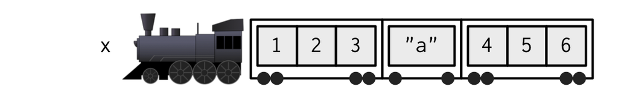

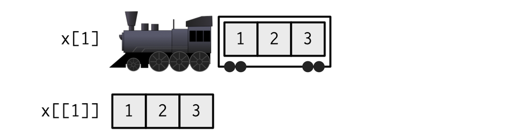

https://adv-r.hadley.nz/subsetting.html

## Data frames and tibbles

Data frames are lists where:

- Each column is a vector
- All vectors have the same length
- Columns represent variables
- Rows represent observations

```r
df <- data.frame(
  name = c("Alice", "Bob", "Josh"),
  age = c(25, 30, 20),
  wears_glasses = c(TRUE, FALSE, TRUE)
)

df
```

```
   name age wears_glasses
1 Alice  25          TRUE
2   Bob  30         FALSE
3  Josh  20          TRUE
```

Tibbles are just modern data frames

## Data frame indexing

- $ selects columns
- [row, col] using numbers, logical vectors, or names

**Note**

Use `!` to negate a logical value (NOT).

```r
df$age
```

```
[1] 25 30 20
```

```r
df[1, ]
```

```
   name age wears_glasses
1 Alice  25          TRUE
```

```r
df[, "name"]
```

```
[1] "Alice" "Bob"   "Josh"
```

```r
df[df$age > 21,]
```

```
   name age wears_glasses
1 Alice  25          TRUE
2   Bob  30         FALSE
```

```r
df[!df$wears_glasses,]
```

```
  name age wears_glasses
2  Bob  30         FALSE
```

## Functions

- Functions are reusable code blocks
- Take inputs and return output

Example: The function `seq()` is used to create a sequence of numbers.

```r
seq(from = 2, to = 8)
```

```
[1] 2 3 4 5 6 7 8
```

### Writing a function is easy

```r
add_one <- function(x) {
  x + 1
}

add_one(10)
```

```
[1] 11
```

## Functions: Documentation

Put the cursor on the function name and press

- F1 for the help page
- F2 for the source code

Notice that some arguments have **default values**.

Similarly, use:

```r
?seq # opens help page
```

```r
sample
```

```
function (x, size, replace = FALSE, prob = NULL)
{
    if (length(x) == 1L && is.numeric(x) && is.finite(x) && x >=
        1) {
        if (missing(size))
            size <- x
        sample.int(x, size, replace, prob)
    }
    else {
        if (missing(size))
            size <- length(x)
        x[sample.int(length(x), size, replace, prob)]
    }
}
<bytecode: 0x0000021365d23540>
<environment: namespace:base>
```

## Functions: Arguments

Arguments are matched first by **name**, then by **position**.

We will use the arguments `from`, `to`, and `by`.

```r
# by position
seq(2,11,3)
```

```
[1]  2  5  8 11
```

```r
# by name
seq(by = 3, from = 2, to = 11)
```

```
[1]  2  5  8 11
```

```r
# mix of both
seq(to = 11, 3, from = 2)
```

```
[1]  2  5  8 11
```

# 3 A data analysis workflow

Welcome to the tidyverse!

## Setup

Go to Tools > Global Options > Workspace.

Check the top-right of your window. You should be working within an **RStudio Project** called `intro-R-course`.

Also check your working directory. It should be the location of the course folder.

```r
getwd()
```

### A fresh start

Also **restart your session** with `Session > Restart R`. Or use the shortcut `Ctrl+Shift+F10`.

## Setup (cont.)

Let’s first check our R version

```r
version
```

```
               _
platform       x86_64-w64-mingw32
arch           x86_64
os             mingw32
crt            ucrt
system         x86_64, mingw32
status
major          4
minor          6.0
year           2026
month          04
day            24
svn rev        89956
language       R
version.string R version 4.6.0 (2026-04-24 ucrt)
nickname       Because it was There
```

## Packages

One of the strengths of R is its vast ecosystem of packages!

- Extend R functionality
- Install once, attach (load) once per session

The tidyverse is a set of R packages that provide a consistent way to work with data. We install and load them with

```r
install.packages("tidyverse")
library(tidyverse)
```

[figure not shown]

[figure not shown]

## The magrittr pipe (%>%)

We use the pipe to pass the result of one operation directly into the next step. **The piped object becomes the first argument of the next function.**

Use the shortcut `Ctrl+Shift+m` to add a pipe.

```r
1:10 %>%
  mean()
```

```
[1] 5.5
```

Which is the same as:

```r
mean(1:10)
```

```
[1] 5.5
```

This is great for chaining operations:

```r
1:10 %>%
  sqrt() %>%
  mean()
```

```
[1] 2.246828
```

This is used often in the tidyverse as many functions use data frames as input AND output.

## Hands-on data analysis

### We take it from here in the `course-script.R` section 3.

- Reading data
- Wrangling with dplyr
  - Regular expressions
- Saving data
- Figures with ggplot2
- Linear model
- PCA
- Heatmap

# 4 Going further

## IPB RStudio Server

### https://rstudio.ipb-halle.de/

- No need to install anything
- Always on
- Powerful

## Topics we did not cover

- Control structures
  - if / else statements
  - `for` loops
- Functional programming for repeated tasks
- Writing reports: Rmarkdown/Quarto
- Version Control: Git and GitHub

## Learning resources

- Tidyverse cheatsheets: https://opensource.posit.co/resources/cheatsheets/
- Books
  - R for Data Science: https://r4ds.hadley.nz/
  - Advanced R: https://adv-r.hadley.nz/
- Online tutorials (blog posts, YouTube)
- R gallery: https://r-graph-gallery.com/

## AI for support

LLMs can be very useful to support your learning.

- Write code snippets
- Explain concepts
- Explain/fix errors
- Find packages/functions for the tasks that you need

RStudio has a built-in AI agent: Posit Assistant.

## Closing

- Final questions?
- Feedback welcome
- There will be an online survey

Let us know if a follow-up course is desired. What topics would you be interested about?

## Attendance (In case you haven’t yet)

Please fill the form!

[figure not shown]

https://forms.office.com/e/SQUs6gXmCZ